首先，推荐jupyter notebook和python，它这个幻灯片形式成为可能

[figure not shown]

*使用 page down 键到下一行*

# 从大的开始讲

提问的时候应当定义答案的形式。 因为其实，所有的答案，是为了问下一个问题，为了解决下一个问题。

```
然后，*研究表明* “我”，这篇幻灯片的写作者，并不是一个可靠的来源。
```

**研究来自，我。*

## 关于我

我习惯性，错误率在50%左右，作为老师的时候，我尽可能的将错误率降到20%。

所以，如果发现我出错了，尽可能指出。

```
*如何知道一个人错了呢？*
这需要构建一个统一的理论，以验证过的知识为基础，并尽可能的不断更新，变得更加符合现实。
```

这玩意是我昨天现做的，所以，嘛，不太好看。

生成这些的源码会和文档一起给，所以可以自己试试做这玩意。

∴有很多有意思的功能

∵我都想试试，所以，画面会有点乱∼∼∼∼∼

## 讲点哲学

世界是由什么构成的？

```
最小的东西拥有基本属性。（化学/物理概念
无中生有是不可能的，一切都是由最小的单位构成，所以宏观的属性是由微观属性决定的。
```

[figure not shown]

## 讲点哲学

然而现代的研究告诉我们，其实总有比小更小，在解释某种事物存在时，总需要牵扯到其它事物。

```
那作为研究者，我们的提问，应当到何时为止呢？

那么就要说明提问的意义，当我问“世界由什么构成”的时候，我可能有更精确的需求，比如说，我如何更稳定的获得食物，如何保护自己不受化学物质伤害，如何实现生命的意义。
```

## 讲点哲学

比如说，下图是一个水的模型，用来解释，为什么水是有极性（表面张力）的，而二氧化碳没有。

```
使用了场的方式来描述电子云，就能解释，而更早期的模型过于简化，就无法解释为啥水是有极性的。
实际上，即使复杂到研究生水平才能理解的模型，也不一定是对的，只是现代的技术发展水平，靠现实的数据，作出的最符合现实的模型。
```

[figure not shown]

*来源https://physics.stackexchange.com/questions/452023/would-an-h-2o-molecule-actually-look-like-this-3d-representation-if-we-could-s*

## 讲点哲学

### 所以，构建模型

使用的模型，除了需要尽可能的精确以外，必须要足够简单，简单，可以让我们在有限的时间里得出结论。

```
所以，精确是次要的，再精密的理论，再好的知识，不能在有限的时间里解决问题，都没有任何意义。
```

理解了这一点之后，就去理解计算机模型。

blender的世界中，一切都是由面构成的。

行吧行吧就这样了，有被无聊到，上手实践吧。

不，稍等，给大家炫耀一下我会用blender做机器人模拟。

[video not shown]

首先，这是个方块。 它有8个角点，6个面。

[figure not shown]

请不要按tab去修改它们，这样太高端了，请从简单的开始。

[figure not shown]

我熟悉的，就，X代表删除，G代表移动，S代表缩放(size)，R代表旋转(rotation)。

建议瞎点一些键试试，我见过的网上视频，每个人的用法都有细微的不同，所以，我也没办法推荐一个“真正好用”的方法。

具体在链接里 https://docs.blender.org/manual/zh-hans/latest/

感兴趣的话，可以自己找教程/看文档

## 讲点哲学

#### 是的，我还没讲完。

在使用blender的过程中，你会感觉到一种自由，和你在学习物理或者数学的时候感受相似，就是，宇宙是由无序和随机构成的。

你的选择几乎是无限的，这意味着，你很可能没有能力区分两种选择的区别。

可以通过限制你的选择的方法，让你尽快的遍历区别较大的选择，了解可能性的分布。

然后对于感受选择的区别，你可以尝试给自己定一个目标，通过完成这个目标，你可以理解自己的每一个选择对于达成目标的贡献，这对于未来可能存在的真正重要的目标的完成，会有帮助。

关于，推荐设置：

[figure not shown]

关于，addon螺丝钉：

[figure not shown]

关于，addon螺丝钉：

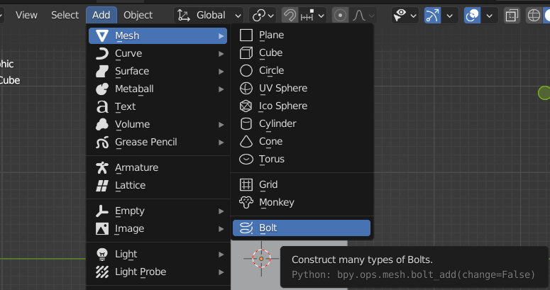

接下来，是有时间才讲的内容。

关于，python中答案的类型

```python
1, 1.0, -1, "一个一个", [1,"一个"], {1:"一个"}
```

```
(1, 1.0, -1, '一个一个', [1, '一个'], {1: '一个'})
```

然而这些数据类型，它们存在的本身没有意义，只有带入到方法当作运行，才使它们具有意义